# Determinants of Prosper's Loan Borrower Rate

### *by Osaze Agho*

## Investigation Overview

> In this investigation, I wanted to explore factors that affect the borrower rate of prosper loans. The main focus was on the prosper score, prosper rating, loan term, and income range.

## Dataset Overview

> The original data consisted of 113,937 loans with 81 variables on each loan. However for the analysis, the data consisted of borrower rate and 12 variables with 2 newly created variables. 29,084 data points were removed from the analysis due to missing information.

## Distribution of Borrower Rate

> Borrower rate in the dataset take on a small range of values, from about 0.04% at the lowest, to about 0.36% at the highest. When plotted, the distribution of borrower rate takes on a unimodal shape with a lot of the data at about 0.32%

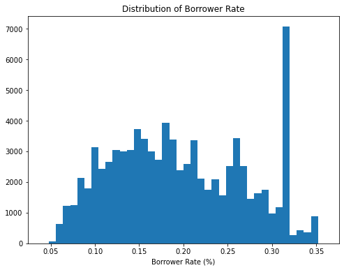

## Distribution of Prosper Rating

> The Prosper Rating assigned at the time the listing was created between AA - HR, with AA being the best, or lowest risk rating. Most prosper loans have a Prosper Rating C, and the lowest number of propser loans having a Prosper Rating of AA with the lowest risk

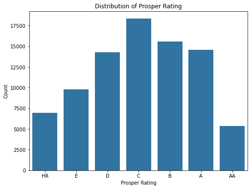

## Borrower Rate and Prosper Rating

> Not surprisngly, there is a negative relationship between Prosper Rating and Borrower Rate. Loans with higher Propser Ratings tend to have lower interest rates. It can also be observed from the violin plot that a huge distribution of loans with the lowest Prosper Rating "HR" have a high Borrower Rate of about 0.32%

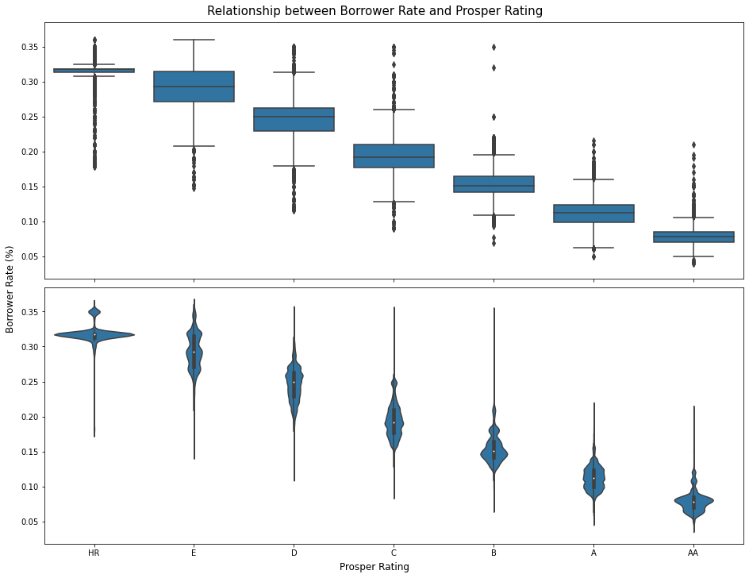

## Relationship between Borrower Rate and variables: Income Range, Homeowner, and Loan Term

> Not surprising, it appears there is a negative relationship between Borrower rate and Income Range. The lower your Income the higher your Interest Rate, with unemployed people having the highest Borrower Rate.

> Likewise there is a relationship between homeowners and Borrower Rate. People that own homes tend to have lower interest rates unlike people without homes.

> It can also be observed that loan term has a positive relationship with Borrower Rate. The 1yr loan term has a significantly lower borrowe rate when compared to a 3yr and 5yr loan term.

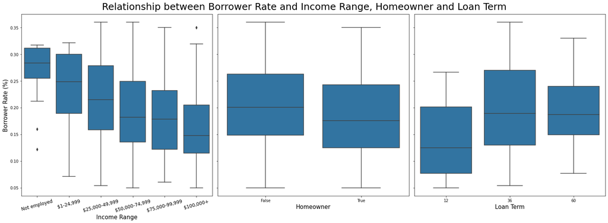

## Borrower Rate by Prosper Score and Income Range

> The higher the prosper score, the lower the borrowers rate as can be seem across all income ranges. Regardless of an individuals income, borrowers with lower propser score tend to have higher interest rates.

> An interesting observation is the minimal difference in borrowers rate for very low prosper scores and very high prosper scores. It can be seen that for propser scores 8 -11, there is a very small difference between the borrowers rate. This observation can also be observed for very low prosper score where the borrowers rate have very small difference across all income ranges. However for Propser scores within 3 and 7, theres seems to be a significant difference between unemployed and the other Income ranges. It seems Income Range is a huge factor with people that fall within prosper scores of 3-7.

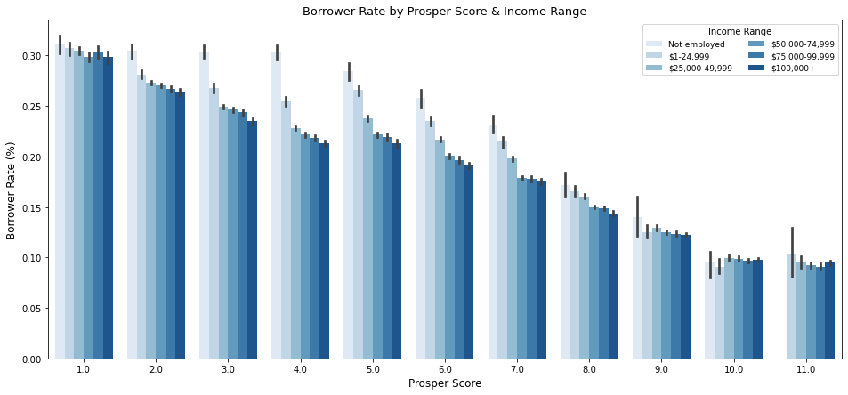

## Borrower Rate by Prosper Rating and Loan Term

> With the exception of prosper ratings HR and E, it can be observed that with loans of the same prosper rating, borrowers rate is directly proportional to loan term. It can be seen that from prosper rating D to AA, loans with the same proper rating have a higher borrowers rate as loan term increases.

> Hence, for borrowers with the same prosper rating, loans with a longer pay off term usually have higher borrowers rate.

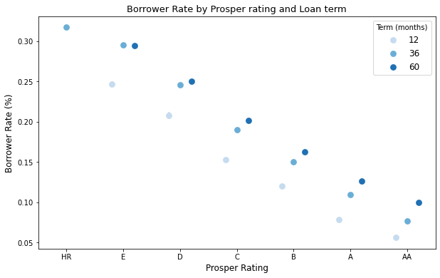

## Borrower Rate by Prosper Rating and Loan Status

> It can be seen that with the exception of prosper rating A, borrowers that are severely delinquent (chargedoff, defaulted) on loan payments usually have higher borrowers rates when compared to other loan status.

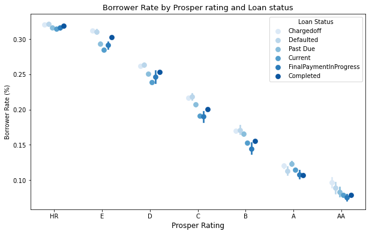